# Регрессионный анализ для бинарных данных

## Мы рассмотрим

- Регрессионный анализ для бинарных зависимых переменных

### Вы сможете

- Построить логистическую регрессионную модель, подобранную методом максимального правдоподобия
- Дать трактовку параметрам логистической регрессионной модели
- Провести анализ девиансы, основанный на логистической регрессии

## Бинарные данные - очень распространенный тип зависимых переменных

- Вид есть - вида нет
- Кто-то в результате эксперимента выжил или умер
- Пойманное животное заражено паразитами или здорово
- Команда выиграла или проиграла

и т.д.

## На каком острове лучше искать ящериц?

[figure not shown]

Пример взят из книги Quinn & Keugh (2002), Оригинальная работа Polis et al. (1998)

```
##     X.ISLAND PARATIO UTA PA PREDICT
## 1       Bota   15.41   P  1   0.555
## 2     Cabeza    5.63   P  1   0.915
## 3    Cerraja   25.92   P  1   0.111
## 4 Coronadito   15.17   A  0   0.568
## 5     Flecha   13.04   P  1   0.678
## 6   Gemelose   18.85   A  0   0.370
```

## Зависит ли встречаемость ящериц от размера острова?

Обычную линейную регрессию подобрать можно,

*Зависимая переменная*: PA - (есть ящерицы "1" - нет ящериц "0")  
*Предиктор* - PARATIO (отношение периметра к площади)

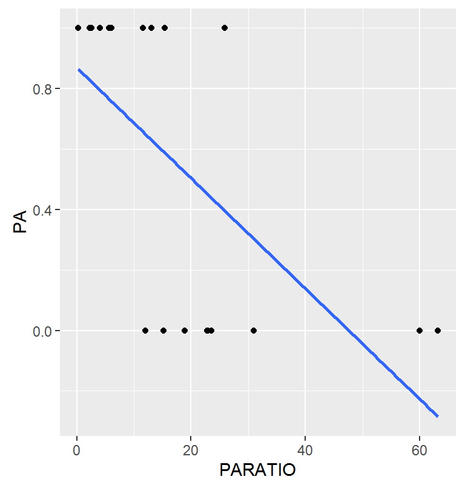

```
##
## Call:
## lm(formula = PA ~ PARATIO, data = liz)
##
## Residuals:
##    Min     1Q Median     3Q    Max
## -0.649 -0.445  0.178  0.264  0.605
##
## Coefficients:
##             Estimate Std. Error t value Pr(>|t|)
## (Intercept)  0.86881    0.14088    6.17  0.00001 ***
## PARATIO     -0.01828    0.00557   -3.28   0.0044 **
## ---
## Signif. codes:  0 '***' 0.001 '**' 0.01 '*' 0.05 '.' 0.1 ' ' 1
##
## Residual standard error: 0.413 on 17 degrees of freedom
## Multiple R-squared:  0.388,  Adjusted R-squared:  0.352
## F-statistic: 10.8 on 1 and 17 DF,  p-value: 0.00438
```

**но она категорически не годится**

## Эти данные лучше описывает логистическая кривая

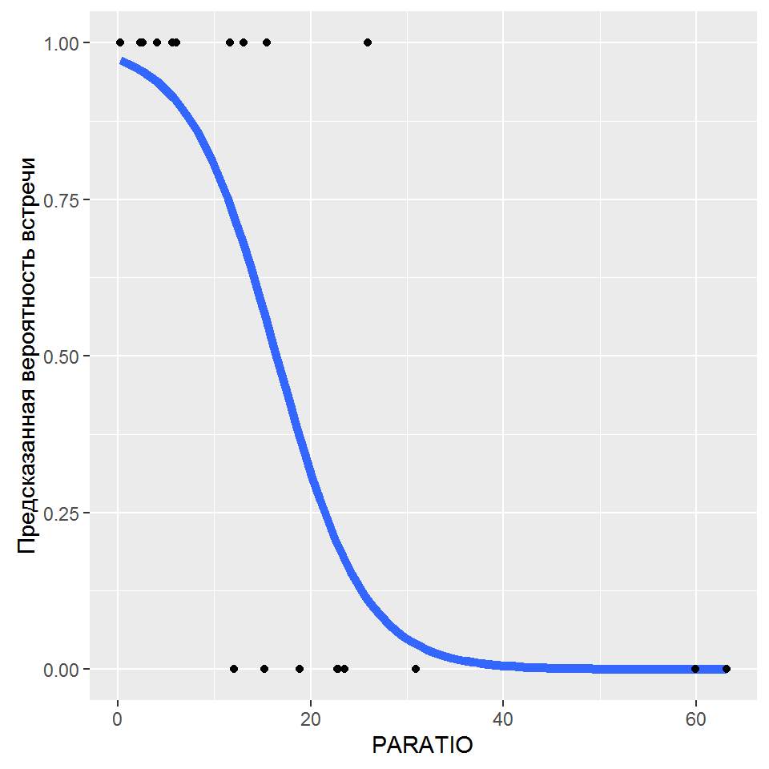

Логистическая кривая описывается такой формулой

\[ \pi(x) = \frac{e^{\beta_0+\beta_1x}}{1+e^{\beta_0+\beta_1x}} \]

## Зависимую величину можно преобразовать в более удобную для моделирования форму

1. Дискретный резульат: 1 или 0
2. Дискретные данные можно преобразовать в форму оценки вероятности события: \(\pi = \frac{N_i}{N_{total}}\), непрерывная аеличина, варьирующая от 0 до 1
3. Вероятность события можно выразить в форме шансов (odds): \(odds=\frac{\pi}{1-\pi}\) варьируют от 0 до \(+\infty\). *NB: Если шансы > 1, то вероятность события, что \(y_i=1\) выше, чем вероятность события \(y_i = 0\). Если шансы < 1, то наоборот*. В обыденной речи мы часто использем фразы, наподобие такой "*шансы на победу 1 к 3*"
4. Шансы преобразуются в *Логиты* (logit): \(ln(odds)=\ln(\frac{\pi}{1-\pi})\) варьируют от \(-\infty\) до \(+\infty\). Логиты гораздо удобнее для построения моделей.

## Что станет с логистической моделью после логит-преобразования?

### Немного алгебры

Обозначим для краткости \(\beta_0 + \beta_1x \equiv z\)

Тогда \[ g(x)=\ln(\frac{\pi(x)}{1-\pi(x)})= \ln(\frac{\frac{e^z}{1+e^z}}{1-\frac{e^z}{1+e^z}}) \]

- \[ g(x)=\ln(\frac{e^z}{1+e^z}) - \ln({1-\frac{e^z}{1+e^z}}) \]
- \[ g(x)=\ln(\frac{e^z}{1+e^z}) - \ln({\frac{1+e^z - e^z}{1+e^z}}) = \ln(\frac{e^z}{1+e^z}) - \ln({\frac{1}{1+e^z}}) \]
- \[ g(x)=\ln(e^z) - \ln(1+e^z) - (\ln(1) -\ln(1+e^z)) \]
- \[ g(x)=\ln(e^z) - \ln(1+e^z) - 0 +\ln(1+e^z) = \ln(e^z) = z \]

## Логистическая модель после логит-преобразования становится линейной

\[ g(x)=\ln(\frac{\pi(x)}{1-\pi(x)})=\beta_0 + \beta_1x\]

Остается только подобрать параметры этой линейной модели: \(\beta_0\) (интерсепт) и \(\beta_1\) (угловой коэффициент)

## Метод максимального правдоподобия

### Вспомним

Если остатки не подчиняется нормальному распределению, то метод наименьших квадратов не работает.  
В этом случае применяют *Метод максимального правдоподбия*

В результате итеративных процедур происходит подбор таких значений коэффициентов, при которых правдоподобие - вероятность получения имеющегося у нас набора данных - оказывается максимальным, при условии справедливости данной модели.

\[ Lik(x_1, ..., x_n) = \Pi^n _{i = 1}f(x_i; \theta)\]

где \(f(x; \theta)\) - функция плотности вероятности с параметрами \(\theta\)

## Правдоподобие для биномиального распределения

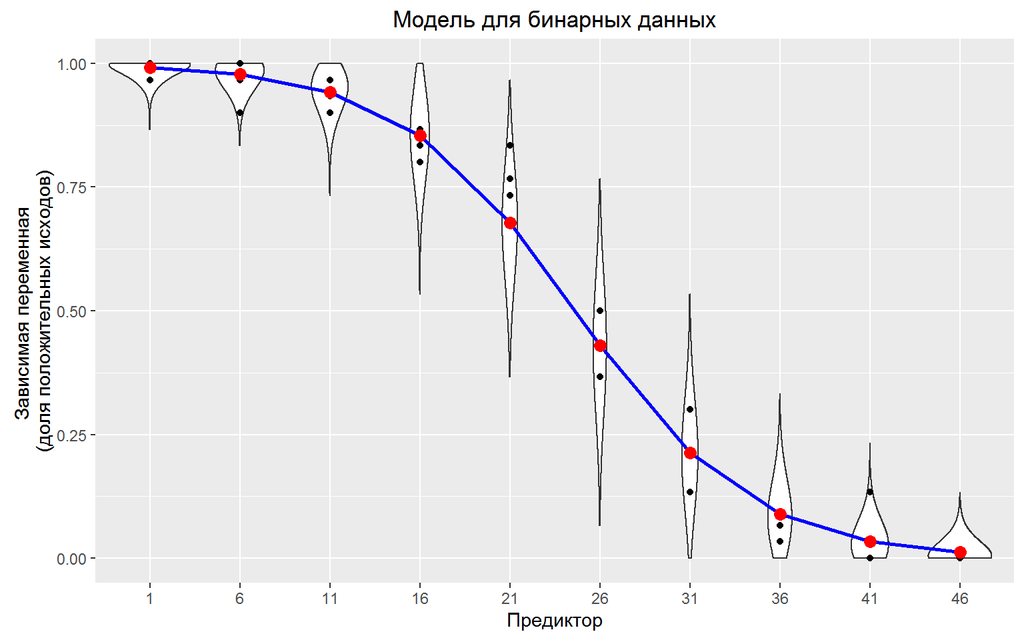

## Функция правдоподобия для биномиального распределения

Для случая биномиального распределения \(x \in Bin(n, \pi)\) функция правдоподобия имеет следующий вид:

\[Lik(\pi|x) = \frac{n!}{(n-x)!x!}\pi^x(1-\pi)^{n-x}\]

отбросив константу, получаем:

\[Lik(\pi|x) \propto \pi^x(1-\pi)^{n-x}\]

### Логарифм правдоподобия

Удобнее работать с логарифмом функции правдоподобия - \(logLik\) - его легче максимизировать. В случае биномиального распределения он выглядит так:

\[logLik(\pi|x) = x log(\pi) + (n-x)log(1-\pi)\]

## Подберем модель

```r
liz_model <- glm(PA ~ PARATIO , family="binomial", data = liz)
summary(liz_model)
```

```
##
## Call:
## glm(formula = PA ~ PARATIO, family = "binomial", data = liz)
##
## Deviance Residuals:
##    Min      1Q  Median      3Q     Max
## -1.607  -0.638   0.237   0.433   2.099
##
## Coefficients:
##             Estimate Std. Error z value Pr(>|z|)
## (Intercept)    3.606      1.695    2.13    0.033 *
## PARATIO       -0.220      0.101   -2.18    0.029 *
## ---
## Signif. codes:  0 '***' 0.001 '**' 0.01 '*' 0.05 '.' 0.1 ' ' 1
##
## (Dispersion parameter for binomial family taken to be 1)
##
##     Null deviance: 26.287  on 18  degrees of freedom
## Residual deviance: 14.221  on 17  degrees of freedom
## AIC: 18.22
##
## Number of Fisher Scoring iterations: 6
```

### `summary()` для модели, подобранной методом максимального правдоподобия

```
##
## Call:
## glm(formula = PA ~ PARATIO, family = "binomial", data = liz)
##
## Deviance Residuals:
##    Min      1Q  Median      3Q     Max
## -1.607  -0.638   0.237   0.433   2.099
##
## Coefficients:
##             Estimate Std. Error z value Pr(>|z|)
## (Intercept)    3.606      1.695    2.13    0.033 *
## PARATIO       -0.220      0.101   -2.18    0.029 *
## ---
## Signif. codes:  0 '***' 0.001 '**' 0.01 '*' 0.05 '.' 0.1 ' ' 1
##
## (Dispersion parameter for binomial family taken to be 1)
##
##     Null deviance: 26.287  on 18  degrees of freedom
## Residual deviance: 14.221  on 17  degrees of freedom
## AIC: 18.22
##
## Number of Fisher Scoring iterations: 6
```

Есть уже знакомые термины: `Estimate`, `Std. Error`, `AIC`  
Появились новые термины: `z value`, `Pr(>|z|)`, `Null deviance`, `Residual deviance`

## "z value"" и "Pr(>z)"

z - это величина критерия Вальда (*Wald statistic*) - аналог t-критерия

Используется для проверки \(H_0: \beta_1=0\)

\[z=\frac{\beta_1}{SE_{\beta_1}}\]

Сравнивают со стандартным нормальным распределением (z-распределение)

Дает надежные оценки p-value при больших выборках

## Null deviance и Residual deviance

Имеющиеся данные позволяют "вписать" три типа моделей

**"Насыщенная" модель** - модель, подразумевающая, что каждая из n точек имеет свой собственный параметр, следовательно надо подобрать n параметров. Вероятность существования данных для такой модели равна 1. \[logLik_{satur}=0\] \[df_{saturated} = n - npar_{saturated} = n - n = 0\]

**"Нулевая" модель** - модель, подразумевающая, что для описания всех точек надо подобрать только 1 параметр. \(g(x) = \beta_0\). \[logLik_{nul} \ne 0\] \[df_{null} = n - npar_{null} = n - 1\]

**"Предложенная" модель** - модель, подобранная в нашем анализе \(g(x) = \beta_0 + \beta_1x\) \[logLik_{prop} \ne 0\] \[df_{proposed} = n - npar_{proposed}\]

## Null deviance и Residual deviance

**Девианса** - это оценка отклонения логарифма максимального правдоподобия одной модели от логарифма максимального правдоподобия другой модели

**Остаточная девианса**:  
\(Dev_{resid} = 2(logLik_{satur} - logLik_{prop})=-2logLik_{prop}\)

**Нулевая девианса**:  
\(Dev_{nul} = 2(logLik_{satur} - logLik_{nul})=-2logLik_{nul}\)

Проверим, совпадут ли со значениями из `summary()`

```r
(Dev_resid <- -2*as.numeric(logLik(liz_model))) #Остаточная девианса
```

```
## [1] 14.2
```

```r
(Dev_nul <- -2*as.numeric(logLik(update(liz_model, ~-PARATIO)))) #Нулевая девианса
```

```
## [1] 26.3
```

## Анализ девиансы

**По соотношению нулевой девиансы и остаточной девиансы можно понять насколько статистически значима модель**

В основе анализа девиансы лежит критерий \(G^2\)

\[ G^2 = -2(logLik_{nul} - logLik_{prop})\]

```r
(G2 <- Dev_nul - Dev_resid)
```

```
## [1] 12.1
```

Вспомним тест отношения правдоподобий: \[ LRT = 2ln(Lik_1/Lik_2) = 2(logLik_1 - logLlik_2)\]

> Тест \(G^2\) - это частный случай теста отношения правдоподобий (Likelihood Ratio Test)

## Свойства критерия \(G^2\)

- \(G^2\) - это девианса полной (предложенной) и редуцированной модели (нулевой)
- \(G^2\) - аналог частного F критерия в обычном регрессионном анализе
- \(G^2\) - подчиняется \(\chi^2\) распределению (с параметом df = 1) если нулевая модель и предложенная модель не отличаются друг от друга.
- \(G^2\) можно использовать для проверки гипотезы о равенстве нулевой и остаточной девианс.

## Задание

1. Вычислите вручную значение критерия \(G^2\) для модели, описывающей встречаемость ящериц (`liz_model`)
2. Оцените уровень значимости для него

\[ G^2 = -2(logLik_{nul} - logLik_{prop})\]

## Решение

```r
#Остаточная девианса
Dev_resid <- -2*as.numeric(logLik(liz_model))

#Нулевая девианса
Dev_nul <- -2*as.numeric(logLik(update(liz_model, ~-PARATIO)))

# Значение критерия
(G2 <- Dev_nul - Dev_resid)
```

```
## [1] 12.1
```

```r
(p_value <- 1 - pchisq(G2, df = 1))
```

```
## [1] 0.000513
```

## Решение с помощью функции `anova()`

```r
anova(liz_model, test="Chi")
```

```
## Analysis of Deviance Table
##
## Model: binomial, link: logit
##
## Response: PA
##
## Terms added sequentially (first to last)
##
##
##         Df Deviance Resid. Df Resid. Dev Pr(>Chi)
## NULL                       18       26.3
## PARATIO  1     12.1        17       14.2  0.00051 ***
## ---
## Signif. codes:  0 '***' 0.001 '**' 0.01 '*' 0.05 '.' 0.1 ' ' 1
```

## Интерпретация коэффициентов логистической регрессии

## Как трактовать коэффициенты подобранной модели?

\[ g(x)=\ln(\frac{\pi(x)}{1-\pi(x)})=\beta_0 + \beta_1x\]

```r
coef(liz_model)
```

```
## (Intercept)     PARATIO
##        3.61       -0.22
```

\(\beta_0\) - не имеет особого смысла, просто поправочный коэффициент

\(\beta_1\) - *на сколько* единиц изменяется логарифм величины шансов (odds), если значение предиктора изменяется на единицу

Трактовать такую величину неудобно и трудно

## Немного алгебры

посмотрим как изменится \(g(x)=\ln(\frac{\pi(x)}{1-\pi(x)})\) при изменении предиктора на 1

\[g(x+1) - g(x) = ln(odds_{x+1}) - ln(odds_x) = ln(\frac{odds_{x+1}}{odds_x})\]

Задание: завершите алгебраическое преобразование

## Решение

\[ln(\frac{odds_{x+1}}{odds_x}) = \beta_0 + \beta_1(x+1) - \beta_0 - \beta_1x = \beta_1\]

\[ln(\frac{odds_{x+1}}{odds_x}) = \beta_1\]

\[\frac{odds_{x+1}}{odds_x} = e^{\beta_1}\]

## Полученная величина имеет определенный смысл

```r
exp(coef(liz_model)[2])
```

```
## PARATIO
##   0.803
```

*Во сколько* раз изменяются шансы встретить ящерицу при увеличении отношения периметра острова к его площади на одну единицу. *NB: Отношение периметра к площади тем больше, чем меньше остров*.

Шансы изменяются в 0.803 раза. То есть, чем больше отношение периметра к площади, тем меньше шансов встретить ящерицу. Значит, чем больше остров, тем больше шансов встретить ящерицу

## Подобранные коэффициенты позволяют построить логистическую кривую

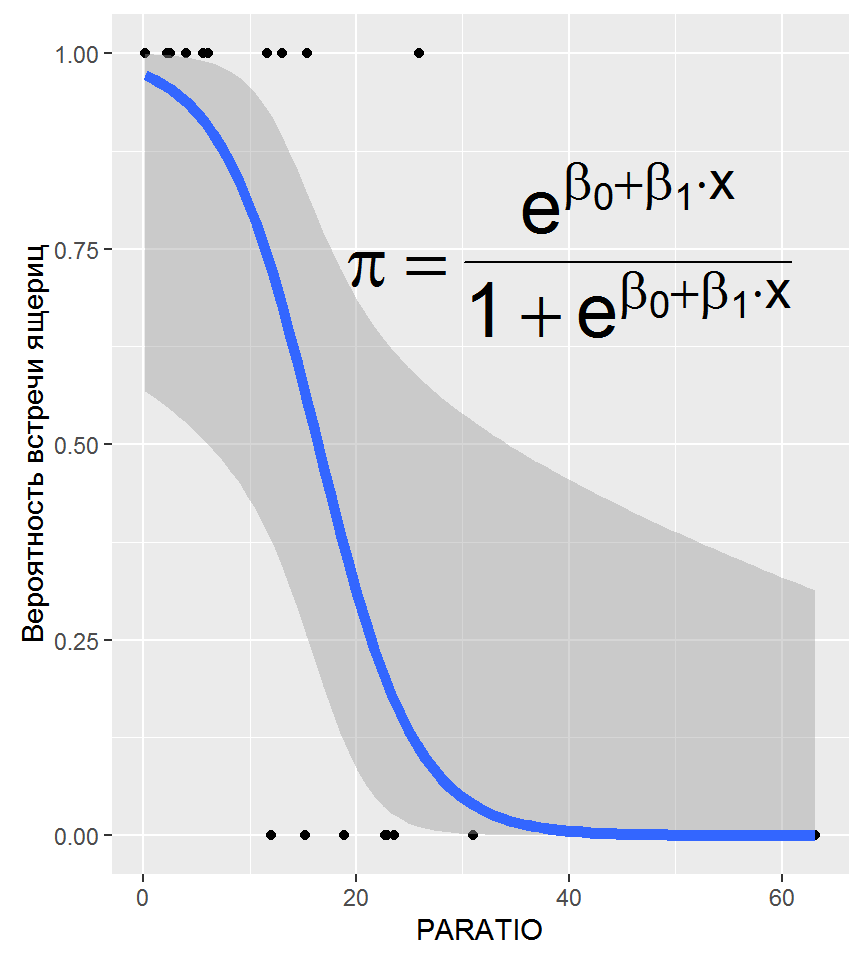

Серая область - доверительный интервал для логистической регрессии

Доверительные интервалы для коэффициентов:

```r
confint(liz_model) # для логитов
```

```
##              2.5 %  97.5 %
## (Intercept)  1.006  8.0421
## PARATIO     -0.485 -0.0665
```

```r
exp(confint(liz_model)) # для отношения шансов
```

```
##             2.5 %   97.5 %
## (Intercept) 2.734 3109.275
## PARATIO     0.616    0.936
```

## Задание:

Постройте график логистической регрессии для модели `liz_model` без использования `geom_smooth()`

Hint 1: Используйте функцию `predict()`, изучите значения параметра "type"

Hint 2: Для вызова справки напишите `predict.glm()`

Hint 3: Создайте датафрейм MyData с переменной `PARATIO`, изменяющейся от минимального до максимального значения `PARATIO`

## Решение

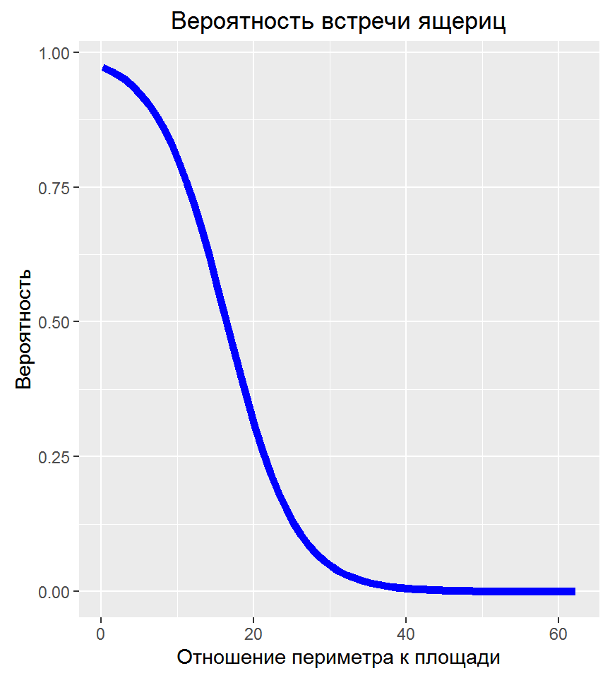

```r
MyData <- data.frame(PARATIO =
        seq(min(liz$PARATIO), max(liz$PARATIO)))

MyData$Predicted <- predict(liz_model,
                            newdata = MyData,
                            type = "response")

ggplot(MyData, aes(x = PARATIO, y = Predicted)) +
  geom_line(size=2, color = "blue") +
  xlab("Отношение периметра к площади") +
  ylab ("Вероятность") +
  ggtitle("Вероятность встречи ящериц")
```

## Применим матричную алгебру для вычисления предсказанных значений и доверительного интервала для линии регрессии

```r
# Создаем искуственный набор данных
MyData <- data.frame(PARATIO = seq(min(liz$PARATIO), max(liz$PARATIO)))

# Формируем модельную матрицу для искуственно созданных данных
X <- model.matrix( ~ PARATIO, data = MyData)
```

## Извлекаем характеристики подобранной модели и получаем предсказанные значения

```r
# Вычисляем параметры подобранной модели и ее матрицу ковариаций
betas    <- coef(liz_model) # Векор коэффицентов
Covbetas <- vcov(liz_model) # Ковариационная матрица

# Вычисляем предсказанные значения, перемножая модельную матрицу на вектор
# коэффициентов
MyData$eta <- X %*% betas
```

## Получаем предсказанные значения

```r
# Переводим предсказанные значения из логитов в вероятности
MyData$Pi  <- exp(MyData$eta) / (1 + exp(MyData$eta))
```

## Вычисляем границы доверительного интервала

```r
# Вычисляем стандартные отшибки путем перемножения матриц
  MyData$se <- sqrt(diag(X %*% Covbetas %*% t(X)))

# Вычисляем доверительные интервалы
MyData$CiUp  <- exp(MyData$eta + 1.96 *MyData$se) /
  (1 + exp(MyData$eta  + 1.96 *MyData$se))

MyData$CiLow  <- exp(MyData$eta - 1.96 *MyData$se) /
  (1 + exp(MyData$eta  - 1.96 *MyData$se))
```

## Строим график

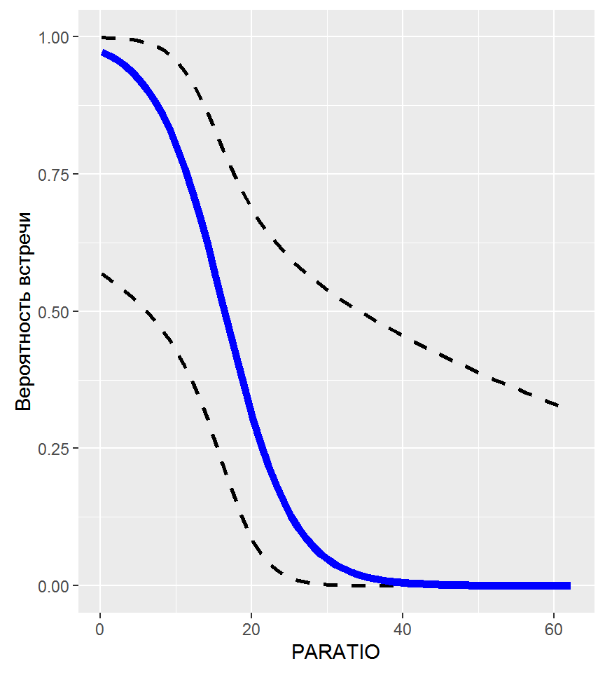

```r
ggplot(MyData, aes(x = PARATIO, y = Pi)) +
  geom_line(aes(x = PARATIO, y = CiUp),
            linetype = 2, size = 1) +
  geom_line(aes(x = PARATIO, y = CiLow),
            linetype = 2, size = 1) +
  geom_line(color = "blue", size=2) +
  ylab("Вероятность встречи")
```

## Множественная логистическая регрессия

## От чего зависит уровень смертности пациентов, выписанных из реанимации?

Данные, полученные на основе изучения 200 историй болезни пациентов одного из американских госпиталей

- STA: Статус (0 = Выжил, 1 = умер)
- AGE: Возраст
- SEX: Пол
- RACE: Раса
- SER: Тип мероприятий в реанимации (0 = Medical, 1 = Surgical)
- CAN: Присутствует ли онкология? (0 = No, 1 = Yes)
- CRN: Присутсвует ли почечная недостаточность (0 = No, 1 = Yes)
- INF: Возможность инфекции (0 = No, 1 = Yes)
- CPR: CPR prior to ICU admission (0 = No, 1 = Yes)
- SYS: Давление во время поступления в реанимацию (in mm Hg)
- HRA: Пульс (beats/min)
- PRE: Была ли госпитализация в предыдущие 6 месяцев (0 = No, 1 = Yes)
- TYP: Тип госпитализации (0 = Elective, 1 = Emergency)
- FRA: Присутствие переломов (0 = No, 1 = Yes)
- PO2: Концентрация кислорода в крови (0 = >60, 1 = ²60)
- PH: Уровень кислотности крови (0 = ³7.25, 1 < 7.25)
- PCO: Концентрция углекислого газа в крови (0 = ²45, 1 = > 45)
- BIC: Bicarbonate from initial blood gases (0 = ³18, 1 = < 18)
- CRE: Уровень креатина (0 = ²2.0, 1 = > 2.0)
- LOC: Уровень сознания пациента при реанимации (0 = no coma or stupor, 1= deep stupor, 2 = coma)

## Смотрим на данные

```r
surviv <- read.table("data/ICU.csv", header=TRUE, sep=";")
head(surviv)
```

```
##   STA AGE    SEX   RAC      SER CAN CRN INF CPR SYS HRA PRE       TYP
## 1   0  27 Female White  Medical  No  No Yes  No 142  88  No Emergency
## 2   0  59   Male White  Medical  No  No  No  No 112  80 Yes Emergency
## 3   0  77   Male White Surgical  No  No  No  No 100  70  No  Elective
## 4   0  54   Male White  Medical  No  No Yes  No 142 103  No Emergency
## 5   0  87 Female White Surgical  No  No Yes  No 110 154 Yes Emergency
## 6   0  69   Male White  Medical  No  No Yes  No 110 132  No Emergency
##   FRA PO2 PH PCO BIC CRE LOC
## 1  No   1  1   1   1   1   1
## 2  No   1  1   1   1   1   1
## 3  No   1  1   1   1   1   1
## 4 Yes   1  1   1   1   1   1
## 5  No   1  1   1   1   1   1
## 6  No   2  1   1   2   1   1
```

## Сделаем факторами те дискретные предикторы, которые обозначенны цифрами

```r
surviv$PO2 <- factor(surviv$PO2)
surviv$PH <- factor(surviv$PH)
surviv$PCO <- factor(surviv$PCO)
surviv$BIC <- factor(surviv$BIC)
surviv$CRE <- factor(surviv$CRE)
surviv$LOC <- factor(surviv$LOC)
```

## Строим модель

```r
M1 <- glm(STA ~ ., family = "binomial", data = surviv)
summary(M1)
```

```
##
## Call:
## glm(formula = STA ~ ., family = "binomial", data = surviv)
##
## Deviance Residuals:
##     Min       1Q   Median       3Q      Max
## -1.5052  -0.5372  -0.1787  -0.0002   3.0171
##
## Coefficients:
##                Estimate Std. Error z value Pr(>|z|)
## (Intercept)   -22.44426 1314.00889   -0.02   0.9864
## AGE             0.05645    0.01848    3.05   0.0023 **
## SEXMale         0.72146    0.54600    1.32   0.1864
## RACOther       16.75746 1314.00721    0.01   0.9898
## RACWhite       16.17455 1314.00665    0.01   0.9902
## SERSurgical    -0.67386    0.62894   -1.07   0.2840
## CANYes          3.48260    1.12114    3.11   0.0019 **
## CRNYes          0.11914    0.84488    0.14   0.8879
## INFYes         -0.10812    0.55570   -0.19   0.8457
## CPRYes          1.03223    0.99008    1.04   0.2971
## SYS            -0.02084    0.00944   -2.21   0.0273 *
## HRA            -0.00292    0.01032   -0.28   0.7776
## PREYes          1.27950    0.70215    1.82   0.0684 .
## TYPEmergency    3.74788    1.34222    2.79   0.0052 **
## FRAYes          1.64945    1.09334    1.51   0.1314
## PO22           -0.67651    0.94017   -0.72   0.4718
## PH2             1.77098    1.21243    1.46   0.1441
## PCO2           -2.08358    1.16463   -1.79   0.0736 .
## BIC2           -0.26235    0.89668   -0.29   0.7698
## CRE2            0.10040    1.13073    0.09   0.9292
## LOC2           37.70527 2486.66692    0.02   0.9879
## LOC3            3.45837    1.34154    2.58   0.0099 **
## ---
## Signif. codes:  0 '***' 0.001 '**' 0.01 '*' 0.05 '.' 0.1 ' ' 1
##
## (Dispersion parameter for binomial family taken to be 1)
##
##     Null deviance: 200.16  on 199  degrees of freedom
## Residual deviance: 112.17  on 178  degrees of freedom
## AIC: 156.2
##
## Number of Fisher Scoring iterations: 17
```

## Задание

Проведите анализ девиансы для данной модели

## Решение

```r
anova(M1, test = "Chi")
```

```
## Analysis of Deviance Table
##
## Model: binomial, link: logit
##
## Response: STA
##
## Terms added sequentially (first to last)
##
##
##      Df Deviance Resid. Df Resid. Dev     Pr(>Chi)
## NULL                   199        200
## AGE   1      7.9       198        192      0.00507 **
## SEX   1      0.0       197        192      0.97572
## RAC   2      1.3       195        191      0.53364
## SER   1      8.3       194        183      0.00392 **
## CAN   1      0.7       193        182      0.39726
## CRN   1      2.6       192        179      0.10559
## INF   1      2.0       191        177      0.15391
## CPR   1      3.9       190        173      0.04777 *
## SYS   1      5.7       189        168      0.01741 *
## HRA   1      0.8       188        167      0.37537
## PRE   1      0.9       187        166      0.33955
## TYP   1     12.8       186        153      0.00035 ***
## FRA   1      0.5       185        153      0.48914
## PO2   1      0.0       184        153      0.87152
## PH    1      0.0       183        153      0.90183
## PCO   1      1.3       182        152      0.25312
## BIC   1      0.1       181        151      0.78999
## CRE   1      0.2       180        151      0.63282
## LOC   2     39.0       178        112 0.0000000034 ***
## ---
## Signif. codes:  0 '***' 0.001 '**' 0.01 '*' 0.05 '.' 0.1 ' ' 1
```

## Упростим модель с помощью функции `step()`

```r
step(M1, direction = "backward")
```

Эта фукнция автоматически применяет функцию `drop1()`, пошагово отбрасывая избыточные предикторы.

## Рассмотрим финальную модель

```r
M2 <- glm(formula = STA ~ AGE + CAN + SYS + TYP + PH + PCO + LOC, family = "binomial",   data = surviv)

# M2 вложена в M1 следовательно их можно сравнить тестом отношения правдоподобий
anova(M1, M2, test = "Chi")
```

```
## Analysis of Deviance Table
##
## Model 1: STA ~ AGE + SEX + RAC + SER + CAN + CRN + INF + CPR + SYS + HRA +
##     PRE + TYP + FRA + PO2 + PH + PCO + BIC + CRE + LOC
## Model 2: STA ~ AGE + CAN + SYS + TYP + PH + PCO + LOC
##   Resid. Df Resid. Dev  Df Deviance Pr(>Chi)
## 1       178        112
## 2       191        123 -13    -11.1      0.6
```

## Вопрос

Во сколько раз изменяется отношение шансов на выживание при условии, что пациент онкологический больной (при прочих равных условиях)?

## Решение

```r
exp(coef(M2)[3])
```

```
## CANYes
##   15.7
```

## Визуализируем предсказания модели

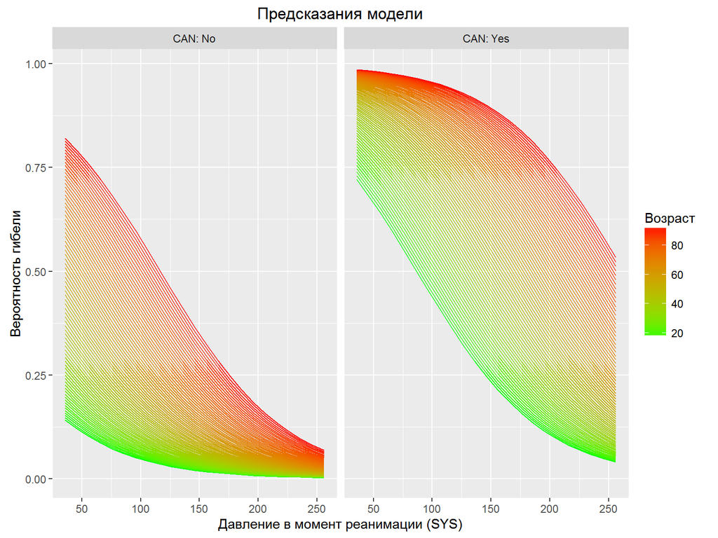

## Диагностика модели

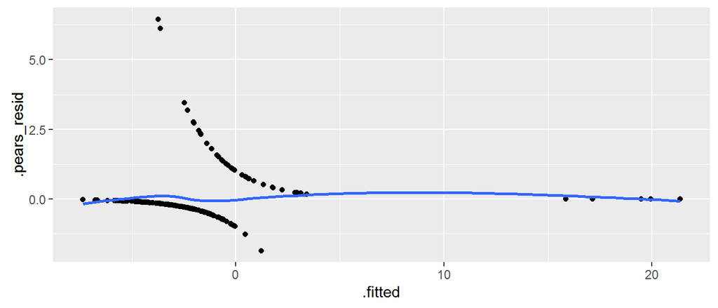

```r
M2_diag <- data.frame(.fitted = predict(M2),
    .pears_resid = residuals(M2, type = "pearson"))

ggplot(M2_diag, aes(x = .fitted, y = .pears_resid)) +
  geom_point() + geom_smooth(se = FALSE)
```

Явного паттерна в остатках нет, но есть другая проблема

## Zero inflation

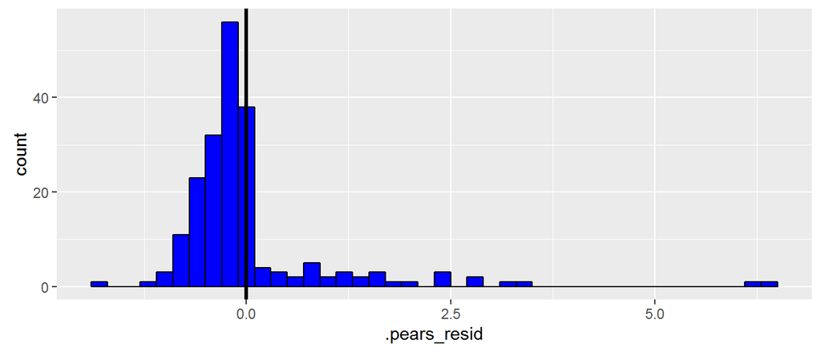

Преобладают отрицательные остатки.  
Это связано с проблемой, называемой *"zero inflation"*, - в зависимой переменной слишком много нулей.

## Сколько должно быть нулей?

```r
#Формируем искусственный набор данных
MyData = expand.grid(
  AGE = seq(min(surviv$AGE),
            max(surviv$AGE), 1),
  CAN = levels(surviv$CAN),
  SYS = seq(min(surviv$SYS),
            max(surviv$SYS), 10),
  TYP =  levels(surviv$TYP),
  PH = levels(surviv$PH),
  PCO = levels(surviv$PCO),
  LOC =levels(surviv$LOC)
  )

# Предсказываем для этих данных вероятности
# гибели в соответствии с моделью M2
Predicted <-predict(M2, newdata = MyData,
                    type ="response")

# Вычисляем долю нулей, ожидаемую
# в соответствии с биномиальным
# распределением
Zero_perc <- sum((1-Predicted))/
  (sum((1-Predicted)) +
    sum((Predicted))) * 100
```

Нулей должно быть 41 %

А в наших данных доля нулей составляет 80 %.

Это больше, чем должно быть в соответствии с биномиальным распределением.

**Нужна более сложная модель!**

## Summary

- При построении модели для бинарной зависимой перменной применяется логистическая регрессия.
- При построении такой модели 1 и 0 в перменной отклика заменяются логитами.
- Угловые коэффициенты подобранной логистической регрессии говорят о том, во сколько раз изменяется соотношение шансов события при увеличении предиктора на единицу.
- Оценить статистическую значимость модели можно с помощью анализа девиансы.

## Что почитать

- Кабаков Р.И. R в действии. Анализ и визуализация данных на языке R. М.: ДМК Пресс, 2014.
- Quinn G.P., Keough M.J. (2002) Experimental design and data analysis for biologists, pp. 92-98, 111-130
- Zuur, A.F. et al. 2009. Mixed effects models and extensions in ecology with R. - Statistics for biology and health. Springer, New York, NY.